```python
import seaborn as sns
import matplotlib.pyplot as plt
import matplotlib.patches as mpatches
import pandas as pd
import numpy as np

from scipy import stats as scipystats
import statsmodels.api
from statsmodels import stats as smstats
import random

att = pd.read_csv('data/Student_Attendance.csv')
growth = pd.read_csv('data/Student_Growth.csv')
dropout = pd.read_csv('data/Student_Dropout.csv')

# Renaming to be concise
att = att.replace('Native Hawaiian/Pacific Islander', 'Hawaiian/Pacific Islander' )
growth = growth.replace('Native Hawaiian/Pacific Islander', 'Hawaiian/Pacific Islander' )
dropout = dropout.replace('Native Hawaiian/Pacific Islander', 'Hawaiian/Pacific Islander' )
```

# Student Attendance

```python
att.info()
att.head(15)
```

```
<class 'pandas.core.frame.DataFrame'>
RangeIndex: 742540 entries, 0 to 742539
Data columns (total 17 columns):
 #   Column                        Non-Null Count   Dtype
---  ------                        --------------   -----
 0   School Year                   742540 non-null  int64
 1   District Code                 742540 non-null  int64
 2   District                      742540 non-null  object
 3   School Code                   742540 non-null  int64
 4   Organization                  742540 non-null  object
 5   Race                          742540 non-null  object
 6   Gender                        742540 non-null  object
 7   Grade                         742540 non-null  object
 8   SpecialDemo                   742540 non-null  object
 9   Geography                     742540 non-null  object
 10  SubGroup                      742540 non-null  object
 11  Rowstatus                     742540 non-null  object
 12  StudentsChronicallyAbsent     371498 non-null  float64
 13  Students                      197054 non-null  float64
 14  PctStudentsChronicallyAbsent  371498 non-null  float64
 15  AvgDaysEnrolled               742540 non-null  float64
 16  AvgDaysAbsent                 742540 non-null  float64
dtypes: float64(5), int64(3), object(9)
memory usage: 96.3+ MB
```

|  | School Year | District Code | District | School Code | Organization | Race | Gender | Grade | SpecialDemo | Geography | SubGroup | Rowstatus | StudentsChronicallyAbsent | Students | PctStudentsChronicallyAbsent | AvgDaysEnrolled | AvgDaysAbsent |
| --- | --- | --- | --- | --- | --- | --- | --- | --- | --- | --- | --- | --- | --- | --- | --- | --- | --- |
| 0 | 2015 | 0 | State of Delaware | 0 | State of Delaware | Hispanic/Latino | All Students | 1st Grade | All Students | All Students | Hispanic/Latino/1st Grade | REPORTED | 252.0 | 2125.0 | 11.86 | 153.871353 | 7.427498 |
| 1 | 2015 | 0 | State of Delaware | 0 | State of Delaware | Hispanic/Latino | All Students | 2nd Grade | All Students | All Students | Hispanic/Latino/2nd Grade | REPORTED | 216.0 | 1898.0 | 11.38 | 153.746528 | 6.742560 |
| 2 | 2015 | 0 | State of Delaware | 0 | State of Delaware | Hispanic/Latino | All Students | 3rd Grade | All Students | All Students | Hispanic/Latino/3rd Grade | REPORTED | 170.0 | 1892.0 | 8.99 | 156.281407 | 6.259296 |
| 3 | 2015 | 0 | State of Delaware | 0 | State of Delaware | Hispanic/Latino | All Students | 4th Grade | All Students | All Students | Hispanic/Latino/4th Grade | REPORTED | 149.0 | 1837.0 | 8.11 | 156.608605 | 6.188699 |
| 4 | 2015 | 0 | State of Delaware | 0 | State of Delaware | Hispanic/Latino | All Students | 5th Grade | All Students | All Students | Hispanic/Latino/5th Grade | REPORTED | 153.0 | 1655.0 | 9.24 | 157.186303 | 6.446895 |
| 5 | 2015 | 0 | State of Delaware | 0 | State of Delaware | Hispanic/Latino | All Students | 6th Grade | All Students | All Students | Hispanic/Latino/6th Grade | REPORTED | 201.0 | 1738.0 | 11.57 | 157.121711 | 7.597588 |
| 6 | 2015 | 0 | State of Delaware | 0 | State of Delaware | Hispanic/Latino | All Students | 7th Grade | All Students | All Students | Hispanic/Latino/7th Grade | REPORTED | 224.0 | 1593.0 | 14.06 | 157.295468 | 8.201208 |
| 7 | 2015 | 0 | State of Delaware | 0 | State of Delaware | Hispanic/Latino | All Students | 8th Grade | All Students | All Students | Hispanic/Latino/8th Grade | REPORTED | 236.0 | 1386.0 | 17.03 | 157.481969 | 8.938974 |
| 8 | 2015 | 0 | State of Delaware | 0 | State of Delaware | Hispanic/Latino | All Students | 9th Grade | All Students | All Students | Hispanic/Latino/9th Grade | REPORTED | 492.0 | 1763.0 | 27.91 | 149.904634 | 12.963901 |
| 9 | 2015 | 0 | State of Delaware | 0 | State of Delaware | Hispanic/Latino | All Students | 10th Grade | All Students | All Students | Hispanic/Latino/10th Grade | REPORTED | 336.0 | 1444.0 | 23.27 | 157.709569 | 11.609838 |
| 10 | 2015 | 0 | State of Delaware | 0 | State of Delaware | Hispanic/Latino | All Students | 11th Grade | All Students | All Students | Hispanic/Latino/11th Grade | REPORTED | 235.0 | 1043.0 | 22.53 | 162.001876 | 12.089118 |
| 11 | 2015 | 0 | State of Delaware | 0 | State of Delaware | Hispanic/Latino | All Students | Twelfth | All Students | All Students | Hispanic/Latino/Twelfth | REPORTED | 335.0 | 1081.0 | 30.99 | 164.574796 | 15.012693 |
| 12 | 2015 | 0 | State of Delaware | 0 | State of Delaware | Hispanic/Latino | All Students | All Students | All Students | All Students | Hispanic/Latino | REPORTED | 3414.0 | 21920.0 | 15.57 | 155.496565 | 8.703340 |
| 13 | 2015 | 0 | State of Delaware | 0 | State of Delaware | Hispanic/Latino | All Students | Kindergarten | All Students | All Students | Hispanic/Latino/Kindergarten | REPORTED | 293.0 | 2013.0 | 14.56 | 149.996318 | 8.211689 |
| 14 | 2015 | 0 | State of Delaware | 0 | State of Delaware | Hispanic/Latino | Female | 1st Grade | Active EL Students | All Students | Hispanic/Latino/Female/1st Grade/Active EL Stu... | REPORTED | 55.0 | 672.0 | 8.18 | 153.518621 | 6.383448 |

```python
unique = att["Race"].unique().tolist()
print(unique)

# Only looking at entire state
att_state = att[ (att["District Code"] == 0)]

# redacted categories like foster care, does not give data or information on absent rate
# fairly certain, by wording of the dictionary, that
att_state =  att_state[att_state['Rowstatus'] != 'REDACTED']

#overall only separate by race for now
att_state_all = att_state[(att_state['Grade'] == 'All Students') &
                      (att_state['Gender'] == 'All Students') &
                      (att_state['SpecialDemo'] == 'All Students') ]

#print(str(att_state_all.loc[ att_state_all['SubGroup'] == 'All Students' , ['School Year','Students'] ]))
att_state_all = att_state_all[ att_state_all['SubGroup'] != 'All Students' ]

#att_state_all = att_state_all.sort_values('PctStudentsChronicallyAbsent')

#att_state_all = att_state_all.set_index('SubGroup')
#ax = att_state_all[att_state_all['School Year'] == 2015].plot.bar(y='PctStudentsChronicallyAbsent', rot=90)

# only data from 2015-2019
att_state_all.head()
```

```
['Hispanic/Latino', 'All Students', 'White', 'Native American', 'African American', 'Asian American', 'Multi-Racial', 'Hawaiian/Pacific Islander']
```

|  | School Year | District Code | District | School Code | Organization | Race | Gender | Grade | SpecialDemo | Geography | SubGroup | Rowstatus | StudentsChronicallyAbsent | Students | PctStudentsChronicallyAbsent | AvgDaysEnrolled | AvgDaysAbsent |
| --- | --- | --- | --- | --- | --- | --- | --- | --- | --- | --- | --- | --- | --- | --- | --- | --- | --- |
| 12 | 2015 | 0 | State of Delaware | 0 | State of Delaware | Hispanic/Latino | All Students | All Students | All Students | All Students | Hispanic/Latino | REPORTED | 3414.0 | 21920.0 | 15.57 | 155.496565 | 8.703340 |
| 327 | 2015 | 0 | State of Delaware | 0 | State of Delaware | Native American | All Students | All Students | All Students | All Students | Native American | REPORTED | 107.0 | 577.0 | 18.54 | 157.167230 | 9.878378 |
| 566 | 2015 | 0 | State of Delaware | 0 | State of Delaware | African American | All Students | All Students | All Students | All Students | African American | REPORTED | 8462.0 | 44747.0 | 18.91 | 153.381503 | 9.189935 |
| 895 | 2015 | 0 | State of Delaware | 0 | State of Delaware | White | All Students | All Students | All Students | All Students | White | REPORTED | 8927.0 | 65198.0 | 13.69 | 161.483502 | 8.661167 |
| 1224 | 2015 | 0 | State of Delaware | 0 | State of Delaware | Asian American | All Students | All Students | All Students | All Students | Asian | REPORTED | 388.0 | 5217.0 | 7.44 | 158.321772 | 6.045994 |

```python
plotOrder = ['Asian', 'White', 'Hawaiian/Pacific Islander', 'Hispanic/Latino','Multi-Racial', 'Native American','African American']
plotOrderReversed = plotOrder[::-1]
sns.set(rc={'figure.figsize':(9,6)})
sns.set_style("ticks")
```

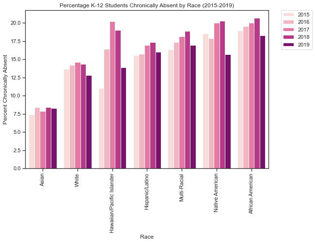

```python
att_plot = sns.barplot(x = 'SubGroup',
                        y = 'PctStudentsChronicallyAbsent',
                        data = att_state_all,
                       hue = 'School Year',
                       palette = "RdPu",
                       order = plotOrder
                      )

for item in att_plot.get_xticklabels(): item.set_rotation(90)
att_plot.set(xlabel='Race', ylabel="Percent Chronically Absent", title="Percentage K-12 Students Chronically Absent by Race (2015-2019)")

plt.legend(bbox_to_anchor=(1.05, 1), loc=2, borderaxespad=0)
plt.show()
```

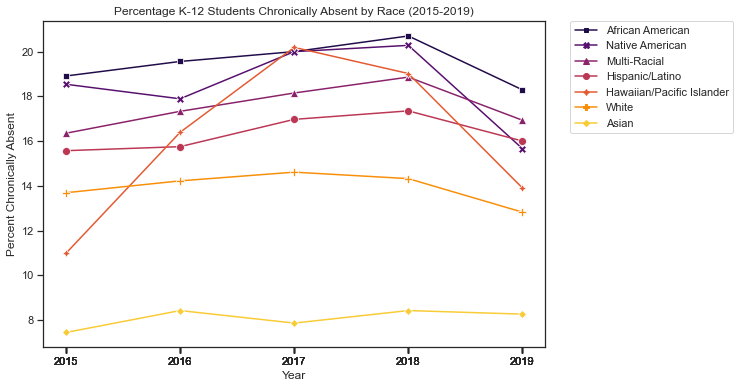

```python
att_plot = sns.lineplot(x = 'School Year',
                        y = 'PctStudentsChronicallyAbsent',
                        data = att_state_all,
                        hue = 'SubGroup',
                        style = 'SubGroup',
                        markers = True,
                        dashes = False,
                        markersize = 8,
                        hue_order = plotOrderReversed,
                        palette = 'inferno'
                      )


att_plot.set_xticks(att_state_all['School Year'].values)
att_plot.set(xlabel='Year', ylabel="Percent Chronically Absent", title="Percentage K-12 Students Chronically Absent by Race (2015-2019)")

plt.legend(bbox_to_anchor=(1.05, 1), loc=2, borderaxespad=0)
plt.show()
```

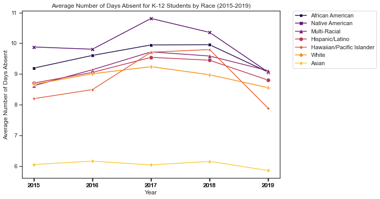

```python
att_plot = sns.lineplot(x = 'School Year',
                        y = 'AvgDaysAbsent',
                        data = att_state_all,
                        hue = 'SubGroup',
                        style = 'SubGroup',
                        markers = True,
                        dashes = False,
                        markersize = 8,
                        hue_order = plotOrderReversed,
                        palette = 'inferno'
                      )

att_plot.set_xticks(att_state_all['School Year'].values)
att_plot.set(xlabel='Year', ylabel="Average Number of Days Absent", title="Average Number of Days Absent for K-12 Students by Race (2015-2019)")

plt.legend(bbox_to_anchor=(1.05, 1), loc=2, borderaxespad=0)
plt.show()
```

### Observations

- Some of the higher chronically absent percentages drop quite a bit from 2018 to 2019
- The hawaiian/pacific islander percentages are really strange, doesn't follow other trends
  - Could be fluctuation due to low numbers?
  - Maybe error in data collection?
  - Look into later
- Across the years, none of the lines have really crossed each other except whatever is happening with hawaiian/pacific islander and one dip for native american students in 2019
  - African American students consistently have the highest percentage of chronic absence
  - Asians and Whites consistently have the lowest percentage of chronic absences
- Mind that other factors besides inequality may affect these rates
  - Such as cultural emphasis on education
  - Possible changes or hiccups in data collection
- Something weird is happening 2019
  - Everything dips by like 1%, maybe changes in data collection?
  - Use 2017-2018

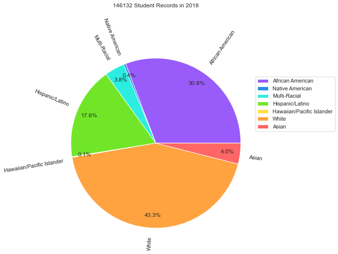

```
Total number of students: 146132

Number of Hawaiian/Pacific Islander students per year
        School Year  Students
1490           2015     164.0
119311         2016     183.0
240457         2017     208.0
363117         2018     205.0
488134         2019     187.0

Number of Native American students per year
        School Year  Students
327            2015     577.0
118156         2016     559.0
239211         2017     550.0
361868         2018     577.0
486853         2019     632.0

Number of Multi-Racial students per year
        School Year  Students
1668           2015    4048.0
119388         2016    4575.0
240489         2017    5019.0
363283         2018    5525.0
488367         2019    6035.0
```

```python
pie_df = att_state_all[['SubGroup','Students','School Year']]
pie_df = pie_df.set_index('SubGroup')
pie_colors = ['#995cfa','#2c8de8','#2bede0',  '#71e629', '#ffdf40','#ffa340','#ff6666']

year = 2018


att_pie_2019 = pie_df[pie_df['School Year'] == year].reindex(plotOrderReversed).plot.pie(
    y='Students',
    figsize=(5, 5),
    labels = plotOrderReversed,
    autopct='%1.1f%%',
    pctdistance=.85,
    radius = 1.6,
    rotatelabels = True,
    ylabel = '',
    colors = pie_colors
)


totalStudents = str(int(pie_df[pie_df['School Year'] == year]['Students'].sum() ) )

plt.title( totalStudents + " Student Records in " + str(year), y=1.5)
plt.legend(bbox_to_anchor=(1.25, 1), loc=2, borderaxespad=0)
plt.show()


print ( "Total number of students: " +  totalStudents)

print("\nNumber of Hawaiian/Pacific Islander students per year")
print(att_state_all.loc[ att_state_all["SubGroup"] == "Hawaiian/Pacific Islander", ['School Year','Students'] ] )

print("\nNumber of Native American students per year")
print(att_state_all.loc[ att_state_all["SubGroup"] == "Native American", ['School Year','Students'] ] )

print("\nNumber of Multi-Racial students per year")
print(att_state_all.loc[ att_state_all["SubGroup"] == "Multi-Racial", ['School Year','Students'] ] )
```

### Note

- Very small percentage of hawaiian/pacific islander students - .1%
- Second smallest is native american students - .4%
  - 160 - 200 ish hawaiian/pacific islander students every year
  - The number of 4% jumps in attendance across years seems like it could be due to low numbers
  - That's like a fluctuation of 6-8 students
  - Could probably test this more
- Realizing this data does not actually give individual attendance records or anything, test score data is probably similar.
  - Can't particularly use any correlation tests for individ students, could by race maybeee
  - https://statisticsbyjim.com/hypothesis-testing/comparing-hypothesis-tests-data-types/
  - ~~Proportion test for significance, poisson? ~~
  - More like 2 sample proportion z-test?

```python
state_2018 = att_state_all[ att_state_all["School Year"] == 2018]

def getCell(sg, column):
    return state_2018[state_2018["SubGroup"] == sg ][column].values[0]

absent_asian = getCell("Asian", "StudentsChronicallyAbsent")
total_asian = getCell("Asian", "Students")

absent_white = getCell("White", "StudentsChronicallyAbsent")
total_white = getCell("White", "Students")

absent_hl = getCell("Hispanic/Latino", "StudentsChronicallyAbsent")
total_hl = getCell("Hispanic/Latino", "Students")

absent_mr = getCell("Multi-Racial", "StudentsChronicallyAbsent")
total_mr = getCell("Multi-Racial", "Students")

absent_na = getCell("Native American", "StudentsChronicallyAbsent")
total_na = getCell("Native American", "Students")

absent_aa = getCell("African American", "StudentsChronicallyAbsent")
total_aa = getCell("African American", "Students")

#test_proportions_2indep(count1, nobs1, count2, nobs2, value=None, method=None, compare='diff',
                        # alternative='two-sided', correction=True, return_results=True)
w_asian = smstats.proportion.test_proportions_2indep(absent_white, total_white, absent_asian, total_asian)
print("\nWhite - Asian")
print("Statistic: " + str(w_asian.statistic))
print("P-value: " + str(w_asian.pvalue))

w_hl = smstats.proportion.test_proportions_2indep(absent_white, total_white, absent_hl, total_hl)
print("\nWhite - Hispanic/Latino")
print("Statistic: " + str(w_hl.statistic))
print("P-value: " + str(w_hl.pvalue))

w_mr = smstats.proportion.test_proportions_2indep(absent_white, total_white, absent_mr, total_mr)
print("\nWhite - Multi-Racial")
print("Statistic: " + str(w_mr.statistic))
print("P-value: " + str(w_mr.pvalue))

w_na = smstats.proportion.test_proportions_2indep(absent_white, total_white, absent_na, total_na)
print("\nWhite - Native American")
print("Statistic: " + str(w_na.statistic))
print("P-value: " + str(w_na.pvalue))

w_aa = smstats.proportion.test_proportions_2indep(absent_white, total_white, absent_aa, total_aa)
print("\nWhite - African American")
print("Statistic: " + str(w_aa.statistic))
print("P-value: " + str(w_aa.pvalue))


# z = 12.062, p = 1.66 ^ -33, p very low, reject null hypothesis that there is no difference, is statistically significant
#print(absent_white, total_white, absent_hl, total_hl)

#ok, a better way of doing this
def printResult(r1, r2):
    absent_r1 = getCell(r1, "StudentsChronicallyAbsent")
    total_r1 = getCell(r1, "Students")
    absent_r2 = getCell(r2, "StudentsChronicallyAbsent")
    total_r2 = getCell(r2, "Students")
    result = smstats.proportion.test_proportions_2indep(absent_r1, total_r1, absent_r2, total_r2)
    print("\n"+r1 + " - " + r2)
    print("Statistic: " + str(result.statistic))
    print("P-value: " + str(result.pvalue))

printResult("Asian", "White")
```

```
White - Asian
Statistic: 15.034090190799574
P-value: 4.390388610167506e-51

White - Hispanic/Latino
Statistic: -11.0805553044355
P-value: 1.5590260991709417e-28

White - Multi-Racial
Statistic: -8.36627023107154
P-value: 5.947072010378869e-17

White - Native American
Statistic: -3.6096000881522983
P-value: 0.00030666943060354195

White - African American
Statistic: -27.005030381660873
P-value: 1.2899466335633519e-160

Asian - White
Statistic: -15.034090190799574
P-value: 4.390388610167506e-51
```

### Observations

- The differences tested are all statistically significant, unless I'm doing the test wrong
- So the difference in chronic attendance rates/proportions are likely not by chance

# Student Dropout

```python
dropout.info()
dropout.head()
```

```
<class 'pandas.core.frame.DataFrame'>
RangeIndex: 24056 entries, 0 to 24055
Data columns (total 15 columns):
 #   Column         Non-Null Count  Dtype
---  ------         --------------  -----
 0   School Year    24056 non-null  int64
 1   District Code  24056 non-null  int64
 2   District       24056 non-null  object
 3   School Code    24056 non-null  int64
 4   Organization   24056 non-null  object
 5   Race           24056 non-null  object
 6   Gender         24056 non-null  object
 7   Grade          24056 non-null  object
 8   SpecialDemo    24056 non-null  object
 9   Geography      24056 non-null  object
 10  SubGroup       24056 non-null  object
 11  RowStatus      24056 non-null  object
 12  Dropouts       3733 non-null   float64
 13  Students       18628 non-null  float64
 14  PctDropouts    3733 non-null   float64
dtypes: float64(3), int64(3), object(9)
memory usage: 2.8+ MB
```

|  | School Year | District Code | District | School Code | Organization | Race | Gender | Grade | SpecialDemo | Geography | SubGroup | RowStatus | Dropouts | Students | PctDropouts |
| --- | --- | --- | --- | --- | --- | --- | --- | --- | --- | --- | --- | --- | --- | --- | --- |
| 0 | 2015 | 0 | State of Delaware | 0 | State of Delaware | Hispanic/Latino | All Students | 9th Grade | All Students | All Students | Hispanic/Latino/9th Grade | REPORTED | 71.0 | 1653.0 | 4.3 |
| 1 | 2015 | 0 | State of Delaware | 0 | State of Delaware | Hispanic/Latino | All Students | 10th Grade | All Students | All Students | Hispanic/Latino/10th Grade | REPORTED | 47.0 | 1347.0 | 3.5 |
| 2 | 2015 | 0 | State of Delaware | 0 | State of Delaware | Hispanic/Latino | All Students | 11th Grade | All Students | All Students | Hispanic/Latino/11th Grade | REPORTED | 20.0 | 1021.0 | 2.0 |
| 3 | 2015 | 0 | State of Delaware | 0 | State of Delaware | Hispanic/Latino | All Students | Twelfth | All Students | All Students | Hispanic/Latino/Twelfth | REPORTED | 20.0 | 965.0 | 2.1 |
| 4 | 2015 | 0 | State of Delaware | 0 | State of Delaware | Hispanic/Latino | All Students | All Students | All Students | All Students | Hispanic/Latino | REPORTED | 158.0 | 4986.0 | 3.2 |

```python
do_state = dropout[ dropout["District Code"] == 0]

do_state = do_state[(do_state['Grade'] == 'All Students') &
                      (do_state['Gender'] == 'All Students') &
                      (do_state['SpecialDemo'] == 'All Students') &
                      (do_state['SubGroup'] != 'All Students')]
do_state.head(30)
```

|  | School Year | District Code | District | School Code | Organization | Race | Gender | Grade | SpecialDemo | Geography | SubGroup | RowStatus | Dropouts | Students | PctDropouts |
| --- | --- | --- | --- | --- | --- | --- | --- | --- | --- | --- | --- | --- | --- | --- | --- |
| 4 | 2015 | 0 | State of Delaware | 0 | State of Delaware | Hispanic/Latino | All Students | All Students | All Students | All Students | Hispanic/Latino | REPORTED | 158.0 | 4986.0 | 3.2 |
| 70 | 2015 | 0 | State of Delaware | 0 | State of Delaware | Native American | All Students | All Students | All Students | All Students | Native American | REPORTED | 6.0 | 151.0 | 4.0 |
| 88 | 2015 | 0 | State of Delaware | 0 | State of Delaware | African American | All Students | All Students | All Students | All Students | African American | REPORTED | 358.0 | 12773.0 | 2.8 |
| 154 | 2015 | 0 | State of Delaware | 0 | State of Delaware | White | All Students | All Students | All Students | All Students | White | REPORTED | 326.0 | 19659.0 | 1.7 |
| 219 | 2015 | 0 | State of Delaware | 0 | State of Delaware | Asian American | All Students | All Students | All Students | All Students | Asian | REDACTED | NaN | 1379.0 | NaN |
| 242 | 2015 | 0 | State of Delaware | 0 | State of Delaware | Hawaiian/Pacific Islander | All Students | All Students | All Students | All Students | Hawaiian/Pacific Islander | REDACTED | NaN | 40.0 | NaN |
| 262 | 2015 | 0 | State of Delaware | 0 | State of Delaware | Multi-Racial | All Students | All Students | All Students | All Students | Multi-Racial | REPORTED | 13.0 | 662.0 | 2.0 |
| 6507 | 2016 | 0 | State of Delaware | 0 | State of Delaware | Hispanic/Latino | All Students | All Students | All Students | All Students | Hispanic/Latino | REPORTED | 119.0 | 5391.0 | 2.2 |
| 6576 | 2016 | 0 | State of Delaware | 0 | State of Delaware | Native American | All Students | All Students | All Students | All Students | Native American | REDACTED | NaN | 153.0 | NaN |
| 6597 | 2016 | 0 | State of Delaware | 0 | State of Delaware | African American | All Students | All Students | All Students | All Students | African American | REPORTED | 239.0 | 12878.0 | 1.9 |
| 6664 | 2016 | 0 | State of Delaware | 0 | State of Delaware | White | All Students | All Students | All Students | All Students | White | REPORTED | 174.0 | 19540.0 | 0.9 |
| 6723 | 2016 | 0 | State of Delaware | 0 | State of Delaware | Asian American | All Students | All Students | All Students | All Students | Asian | REDACTED | NaN | 1435.0 | NaN |
| 6735 | 2016 | 0 | State of Delaware | 0 | State of Delaware | Hawaiian/Pacific Islander | All Students | All Students | All Students | All Students | Hawaiian/Pacific Islander | REDACTED | NaN | 45.0 | NaN |
| 6744 | 2016 | 0 | State of Delaware | 0 | State of Delaware | Multi-Racial | All Students | All Students | All Students | All Students | Multi-Racial | REPORTED | 7.0 | 845.0 | 0.8 |
| 11663 | 2017 | 0 | State of Delaware | 0 | State of Delaware | Hispanic/Latino | All Students | All Students | All Students | All Students | Hispanic/Latino | REPORTED | 161.0 | 5968.0 | 2.7 |
| 11734 | 2017 | 0 | State of Delaware | 0 | State of Delaware | Native American | All Students | All Students | All Students | All Students | Native American | REDACTED | NaN | 164.0 | NaN |
| 11751 | 2017 | 0 | State of Delaware | 0 | State of Delaware | African American | All Students | All Students | All Students | All Students | African American | REPORTED | 281.0 | 12912.0 | 2.2 |
| 11824 | 2017 | 0 | State of Delaware | 0 | State of Delaware | White | All Students | All Students | All Students | All Students | White | REPORTED | 234.0 | 19310.0 | 1.2 |
| 11893 | 2017 | 0 | State of Delaware | 0 | State of Delaware | Asian American | All Students | All Students | All Students | All Students | Asian | REPORTED | 5.0 | 1535.0 | 0.3 |
| 11916 | 2017 | 0 | State of Delaware | 0 | State of Delaware | Hawaiian/Pacific Islander | All Students | All Students | All Students | All Students | Hawaiian/Pacific Islander | REDACTED | NaN | 49.0 | NaN |
| 11926 | 2017 | 0 | State of Delaware | 0 | State of Delaware | Multi-Racial | All Students | All Students | All Students | All Students | Multi-Racial | REPORTED | 14.0 | 946.0 | 1.5 |
| 17787 | 2018 | 0 | State of Delaware | 0 | State of Delaware | Hispanic/Latino | All Students | All Students | All Students | All Students | Hispanic/Latino | REPORTED | 159.0 | 6468.0 | 2.5 |
| 17860 | 2018 | 0 | State of Delaware | 0 | State of Delaware | Native American | All Students | All Students | All Students | All Students | Native American | REDACTED | NaN | 190.0 | NaN |
| 17896 | 2018 | 0 | State of Delaware | 0 | State of Delaware | African American | All Students | All Students | All Students | All Students | African American | REPORTED | 258.0 | 13138.0 | 2.0 |
| 17970 | 2018 | 0 | State of Delaware | 0 | State of Delaware | White | All Students | All Students | All Students | All Students | White | REPORTED | 253.0 | 19156.0 | 1.3 |
| 18047 | 2018 | 0 | State of Delaware | 0 | State of Delaware | Asian American | All Students | All Students | All Students | All Students | Asian | REDACTED | NaN | 1576.0 | NaN |
| 18072 | 2018 | 0 | State of Delaware | 0 | State of Delaware | Hawaiian/Pacific Islander | All Students | All Students | All Students | All Students | Hawaiian/Pacific Islander | REDACTED | NaN | 51.0 | NaN |
| 18082 | 2018 | 0 | State of Delaware | 0 | State of Delaware | Multi-Racial | All Students | All Students | All Students | All Students | Multi-Racial | REPORTED | 12.0 | 1014.0 | 1.2 |

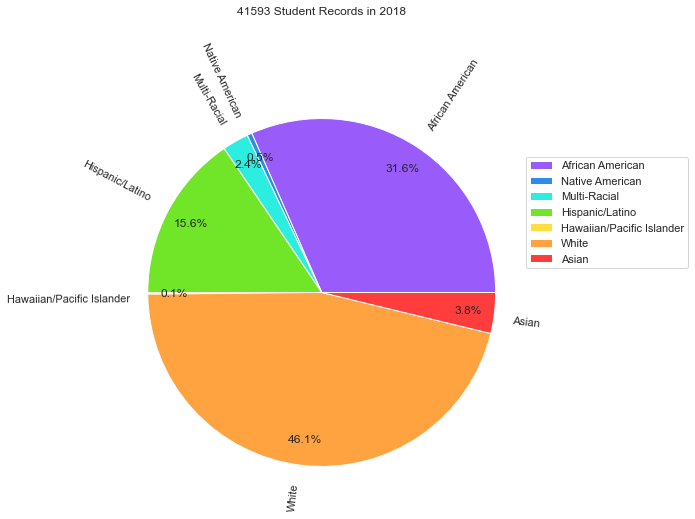

```
Total number of students: 41593
```

```python
plotOrder = ['Asian', 'White', 'Hawaiian/Pacific Islander' , 'Hispanic/Latino','Multi-Racial', 'Native American','African American']
plotOrderReversed = plotOrder[::-1]

pie_df = do_state[['SubGroup','Students','School Year']]
pie_df = do_state.set_index('SubGroup')
pie_colors = ['#995cfa','#2c8de8','#2bede0',  '#71e629', '#ffdf40','#ffa340','#ff3d3d']

do_pie_2018 = pie_df[pie_df['School Year'] == 2018].reindex(plotOrderReversed).plot.pie(
    y='Students',
    figsize=(5, 5),
    labels = plotOrderReversed,
    autopct='%1.1f%%',
    pctdistance=.85,
    radius = 1.6,
    rotatelabels = True,
    ylabel = '',
    colors = pie_colors
)

totalStudents = str(int(pie_df[pie_df['School Year'] == 2018]['Students'].sum() ) )

plt.title( totalStudents + " Student Records in 2018", y=1.5)
plt.legend(bbox_to_anchor=(1.25, 1), loc=2, borderaxespad=0)
plt.show()


print ( "Total number of students: " +  totalStudents)

#print("\nNumber of Native American students per year")
#print(att_state_all.loc[ att_state_all["SubGroup"] == "Native American", ['School Year','Students'] ] )
```

### Notes

- Unsure why, but the dropout info for Asians, Hawaiian/Pacific Islander, and Native Americans is mostly redacted
  - Possibly no one dropping out, but why not include the info?
  - Dictionary says redacted may be to comply with privacy laws
  - Few students n or few students dropping out, easier to point out who exactly
- This data only goes up to 2018
- The percentage of students across races looks relatively the same
  - Though the sample is smaller for this dataset, I wonder why

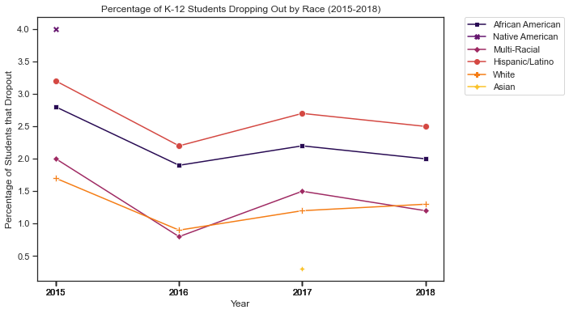

```python
# get rid of all rows without dropout rate report
do_state =  do_state[do_state['RowStatus'] != 'REDACTED']

# same order, sans hawaiian / pacific islander because redacted (no dropout numbers reported)
doOrder = ['Asian', 'White', 'Hispanic/Latino','Multi-Racial', 'Native American','African American']
doOrderReversed = doOrder[::-1]

do_plot = sns.lineplot(x = 'School Year',
                        y = 'PctDropouts',
                        data = do_state,
                        hue = 'SubGroup',
                        style = 'SubGroup',
                        markers = True,
                        dashes = False,
                        markersize = 8,
                        hue_order = doOrderReversed,
                        palette = 'inferno'
                      )


do_plot.set_xticks(do_state['School Year'].values)
do_plot.set(xlabel='Year', ylabel="Percentage of Students that Dropout", title="Percentage of K-12 Students Dropping Out by Race (2015-2018)")

plt.legend(bbox_to_anchor=(1.05, 1), loc=2, borderaxespad=0)
plt.show()
```

### Observations

- Again the lines, ignoring multi-racial students, don't really cross one another across four years
  - Probably another statistically significant difference here?
- With what I read about the disparity of African American students' test scores, I'm surprised to see that Hispanic/Latino students are dropping out at a consistently higher rate
  - I wonder if there've been any papers focusing on this

```python
state_2018 = do_state[ do_state["School Year"] == 2018]

def getCell(sg, column):
    return state_2018[state_2018["SubGroup"] == sg ][column].values[0]

def printResult(r1, r2):
    do_r1 = getCell(r1, "Dropouts")
    total_r1 = getCell(r1, "Students")
    do_r2 = getCell(r2, "Dropouts")
    total_r2 = getCell(r2, "Students")
    result = smstats.proportion.test_proportions_2indep(do_r1, total_r1, do_r2, total_r2)
    print("\n"+r1 + " - " + r2)
    print("Statistic: " + str(result.statistic))
    print("P-value: " + str(result.pvalue))

printResult("White", "Multi-Racial")
printResult("White", "African American")
printResult("White", "Hispanic/Latino")
```

```
White - Multi-Racial
Statistic: 0.12781694850366937
P-value: 0.8982938371137804

White - African American
Statistic: -4.397225547129152
P-value: 1.0964339292783051e-05

White - Hispanic/Latino
Statistic: -5.462220319536354
P-value: 4.7021598729772016e-08
```

## Student Growth

```python
growth.info()
growth.head(15)
```

```
<class 'pandas.core.frame.DataFrame'>
RangeIndex: 26878 entries, 0 to 26877
Data columns (total 15 columns):
 #   Column             Non-Null Count  Dtype
---  ------             --------------  -----
 0   SchoolYear         26878 non-null  int64
 1   District Code      26878 non-null  int64
 2   District           26878 non-null  object
 3   School Code        26878 non-null  int64
 4   Organization       26878 non-null  object
 5   Race               26878 non-null  object
 6   Gender             26878 non-null  object
 7   Grade              26878 non-null  object
 8   SpecialDemo        26878 non-null  object
 9   Geography          26878 non-null  object
 10  SubGroup           26878 non-null  object
 11  Category           26878 non-null  object
 12  RowStatus          26878 non-null  object
 13  Students           13938 non-null  float64
 14  AvgPctOfTargetMet  13938 non-null  float64
dtypes: float64(2), int64(3), object(10)
memory usage: 3.1+ MB
```

|  | SchoolYear | District Code | District | School Code | Organization | Race | Gender | Grade | SpecialDemo | Geography | SubGroup | Category | RowStatus | Students | AvgPctOfTargetMet |
| --- | --- | --- | --- | --- | --- | --- | --- | --- | --- | --- | --- | --- | --- | --- | --- |
| 0 | 2019 | 77 | Sussex Academy | 0 | Sussex Academy | All Students | Male | All Students | All Students | All Students | Male | School Growth - Math | REPORTED | 159.0 | 63.8868 |
| 1 | 2019 | 77 | Sussex Academy | 0 | Sussex Academy | Asian American | All Students | All Students | All Students | All Students | Asian | School Growth - ELA | REDACTED | NaN | NaN |
| 2 | 2019 | 77 | Sussex Academy | 0 | Sussex Academy | Asian American | All Students | All Students | All Students | All Students | Asian | School Growth - Math | REDACTED | NaN | NaN |
| 3 | 2019 | 77 | Sussex Academy | 576 | Sussex Academy | All Students | Male | All Students | All Students | All Students | Male | School Growth - ELA | REPORTED | 159.0 | 68.4214 |
| 4 | 2019 | 77 | Sussex Academy | 576 | Sussex Academy | All Students | Male | All Students | All Students | All Students | Male | School Growth - Math | REPORTED | 159.0 | 63.8868 |
| 5 | 2019 | 77 | Sussex Academy | 576 | Sussex Academy | Asian American | All Students | All Students | All Students | All Students | Asian | School Growth - ELA | REDACTED | NaN | NaN |
| 6 | 2019 | 77 | Sussex Academy | 576 | Sussex Academy | Asian American | All Students | All Students | All Students | All Students | Asian | School Growth - Math | REDACTED | NaN | NaN |
| 7 | 2018 | 0 | State of Delaware | 0 | State of Delaware | African American | All Students | All Students | All Students | All Students | African American | Progress Toward English Language Proficiency | REPORTED | 735.2 | 69.4558 |
| 8 | 2018 | 0 | State of Delaware | 0 | State of Delaware | African American | All Students | All Students | All Students | All Students | African American | School Growth - ELA | REPORTED | 14041.0 | 57.8010 |
| 9 | 2018 | 0 | State of Delaware | 0 | State of Delaware | African American | All Students | All Students | All Students | All Students | African American | School Growth - Math | REPORTED | 14039.0 | 50.9266 |
| 10 | 2018 | 0 | State of Delaware | 0 | State of Delaware | African American | All Students | All Students | All Students | All Students | African American | School Growth Highest Quartile - ELA | REPORTED | 4346.0 | 54.4834 |
| 11 | 2018 | 0 | State of Delaware | 0 | State of Delaware | African American | All Students | All Students | All Students | All Students | African American | School Growth Highest Quartile - Math | REPORTED | 4396.0 | 48.9286 |
| 12 | 2018 | 0 | State of Delaware | 0 | State of Delaware | African American | All Students | All Students | All Students | All Students | African American | School Growth Lowest Quartile - ELA | REPORTED | 4010.0 | 62.9499 |
| 13 | 2018 | 0 | State of Delaware | 0 | State of Delaware | African American | All Students | All Students | All Students | All Students | African American | School Growth Lowest Quartile - Math | REPORTED | 3929.0 | 56.3561 |
| 14 | 2018 | 0 | State of Delaware | 0 | State of Delaware | All Students | All Students | All Students | Active EL Students | All Students | English Learners | Progress Toward English Language Proficiency | REPORTED | 8858.6 | 70.4030 |

```python
#only 2018 - 2019 data
growth_state = growth[ growth["District Code"] == 0]

growth_state = growth_state[(growth_state['Grade'] == 'All Students') &
                      (growth_state['Gender'] == 'All Students') &
                      (growth_state['SpecialDemo'] == 'All Students') &
                      (growth_state['SubGroup'] != 'All Students')]

growth_state['Total'] = 100
#for proportion test later
growth_state['AvgNumTargetMet'] = ( growth_state['AvgPctOfTargetMet'] / 100 ) * growth_state['Students']
growth_ela = growth_state[ (growth_state['Category'] == 'School Growth - ELA') &  (growth_state['SchoolYear'] == 2018)]
growth_math = growth_state[ (growth_state['Category'] == 'School Growth - Math') &  (growth_state['SchoolYear'] == 2018) ]
growth_ela.head()
```

|  | SchoolYear | District Code | District | School Code | Organization | Race | Gender | Grade | SpecialDemo | Geography | SubGroup | Category | RowStatus | Students | AvgPctOfTargetMet | Total | AvgNumTargetMet |
| --- | --- | --- | --- | --- | --- | --- | --- | --- | --- | --- | --- | --- | --- | --- | --- | --- | --- |
| 8 | 2018 | 0 | State of Delaware | 0 | State of Delaware | African American | All Students | All Students | All Students | All Students | African American | School Growth - ELA | REPORTED | 14041.0 | 57.8010 | 100 | 8115.838410 |
| 44 | 2018 | 0 | State of Delaware | 0 | State of Delaware | Asian American | All Students | All Students | All Students | All Students | Asian | School Growth - ELA | REPORTED | 1704.0 | 76.4689 | 100 | 1303.030056 |
| 50 | 2018 | 0 | State of Delaware | 0 | State of Delaware | Hispanic/Latino | All Students | All Students | All Students | All Students | Hispanic/Latino | School Growth - ELA | REPORTED | 8327.0 | 60.7889 | 100 | 5061.891703 |
| 57 | 2018 | 0 | State of Delaware | 0 | State of Delaware | Multi-Racial | All Students | All Students | All Students | All Students | Multi-Racial | School Growth - ELA | REPORTED | 1897.0 | 62.4634 | 100 | 1184.930698 |
| 64 | 2018 | 0 | State of Delaware | 0 | State of Delaware | Native American | All Students | All Students | All Students | All Students | Native American | School Growth - ELA | REPORTED | 178.0 | 60.6854 | 100 | 108.020012 |

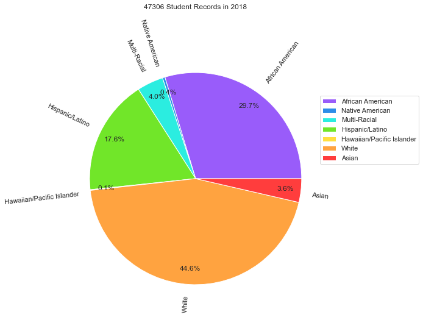

```
Total number of students: 47306
```

```python
pie_df = growth_ela[['SubGroup','Students','SchoolYear']]
pie_df = growth_ela.set_index('SubGroup')

growth_pie_2018 = pie_df[pie_df['SchoolYear'] == 2018].reindex(plotOrderReversed).plot.pie(
    y='Students',
    figsize=(5, 5),
    labels = plotOrderReversed,
    autopct='%1.1f%%',
    pctdistance=.85,
    radius = 1.6,
    rotatelabels = True,
    ylabel = '',
    colors = pie_colors
)

totalStudents = str(int(pie_df[pie_df['SchoolYear'] == 2018]['Students'].sum() ) )

plt.title( totalStudents + " Student Records in 2018", y=1.5)
plt.legend(bbox_to_anchor=(1.25, 1), loc=2, borderaxespad=0)
plt.show()


print ( "Total number of students: " +  totalStudents)
```

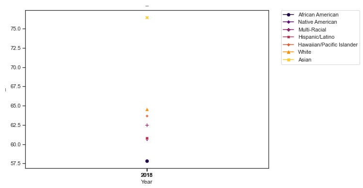

```python
doOrder = ['Asian', 'White', 'Hispanic/Latino','Multi-Racial', 'Native American','African American']
doOrderReversed = doOrder[::-1]

ela_plot = sns.lineplot(x = 'SchoolYear',
                        y = 'AvgPctOfTargetMet',
                        data = growth_ela,
                        hue = 'SubGroup',
                        style = 'SubGroup',
                        markers = True,
                        dashes = False,
                        markersize = 8,
                        hue_order = plotOrderReversed,
                        palette = 'inferno'
                      )


ela_plot.set_xticks(growth_ela['SchoolYear'].values)
ela_plot.set(xlabel='Year', ylabel="--", title="--")

plt.legend(bbox_to_anchor=(1.05, 1), loc=2, borderaxespad=0)
plt.show()
#ok, this would not work well as line graph, there's only 2018 and 2019
```

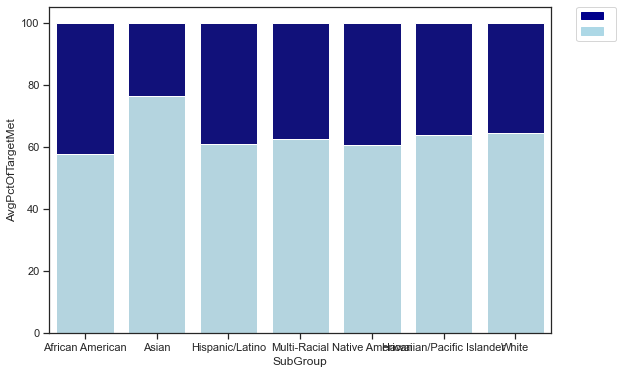

```python
bar1 = sns.barplot(x="SubGroup",  y="Total", data=growth_ela, color='darkblue')
bar2 = sns.barplot(x="SubGroup",  y="AvgPctOfTargetMet", data=growth_ela, color='lightblue')

# Legend creation
top_bar = mpatches.Patch(color='darkblue', label='')
bottom_bar = mpatches.Patch(color='lightblue', label='')
plt.legend(handles=[top_bar, bottom_bar],bbox_to_anchor=(1.05, 1), loc=2, borderaxespad=0)

plt.show()
# ehh graph seems a little confusing maybe
```

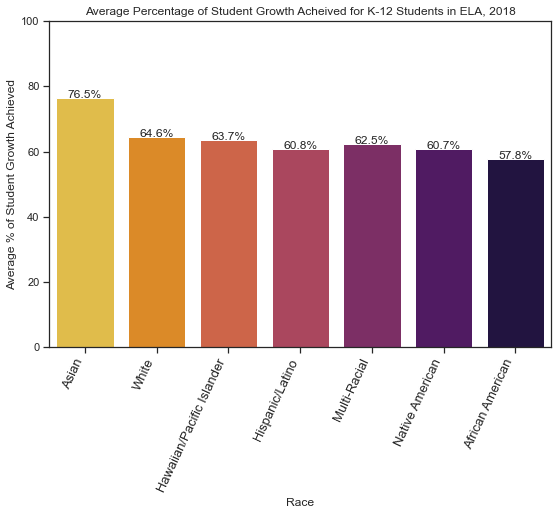

```python
ela_plot = sns.barplot(x = 'SubGroup',
                        y = 'AvgPctOfTargetMet',
                        data = growth_ela,
                       palette = "inferno_r",
                       order = plotOrder
                    )

ela_plot.set(xlabel='Race', ylabel='Average % of Student Growth Achieved', title="Average Percentage of Student Growth Acheived for K-12 Students in ELA, 2018")
ela_plot.set(ylim=(0, 100))
ela_plot.set_xticklabels(ela_plot.get_xticklabels(), rotation=65, ha="right", fontsize=13)

#labels on bars
for p in ela_plot.patches:
    ela_plot.annotate(str(format(p.get_height(), '.1f'))+"%",
                   (p.get_x() + p.get_width() / 2., p.get_height()),
                   ha = 'center')
plt.show()
```

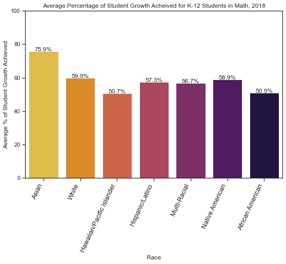

```python
math_plot = sns.barplot(x = 'SubGroup',
                        y = 'AvgPctOfTargetMet',
                        data = growth_math,
                       palette = "inferno_r",
                       order = plotOrder
                    )

math_plot.set(xlabel='Race', ylabel='Average % of Student Growth Achieved', title="Average Percentage of Student Growth Acheived for K-12 Students in Math, 2018")
math_plot.set(ylim=(0, 100))
math_plot.set_xticklabels(math_plot.get_xticklabels(), rotation=65, ha="right", fontsize=13)

#labels on bars
for p in math_plot.patches:
    math_plot.annotate(str(format(p.get_height(), '.1f'))+"%",
                   (p.get_x() + p.get_width() / 2., p.get_height()),
                   ha = 'center')
plt.show()
```

```python
def getCell(sg, column, df):
    return df[df["SubGroup"] == sg ][column].values[0]

def printResult(df, r1, r2):
    part_r1 = getCell(r1, "AvgNumTargetMet",df)
    total_r1 = getCell(r1, "Students",df)
    part_r2 = getCell(r2, "AvgNumTargetMet",df)
    total_r2 = getCell(r2, "Students",df)
    result = smstats.proportion.test_proportions_2indep(part_r1, total_r1, part_r2, total_r2)
    print("\n"+r1 + " - " + r2)
    print("Statistic: " + str(result.statistic))
    print("P-value: " + str(result.pvalue))

print("Using an alpha level of .05 : ")
print("Not statistically significant, unable to reject the null hypothesis that the two proportions are equal:")
printResult(growth_ela,"White", "Multi-Racial")
printResult(growth_ela,"White", "Native American")

print("\nStatistically significant, the two proportions are different:")
printResult(growth_ela,"White", "Asian")
printResult(growth_ela,"White", "Hispanic/Latino")
printResult(growth_ela,"White", "African American")

print("\nUsing an alpha level of .05 : ")
print("Not statistically significant, unable to reject the null hypothesis that the two proportions are equal:")
printResult(growth_math,"White", "Native American")

print("\nStatistically significant, the two proportions are different:")
printResult(growth_math,"White", "Asian")
printResult(growth_math,"White", "Multi-Racial")
printResult(growth_math,"White", "Hispanic/Latino")
printResult(growth_math,"White", "African American")

#waittttt wait
```

```
Using an alpha level of .05 :
Not statistically significant, unable to reject the null hypothesis that the two proportions are equal:

White - Multi-Racial
Statistic: 1.8508215273104927
P-value: 0.064195233012805

White - Native American
Statistic: 1.1014898487522609
P-value: 0.2706835201648776

Statistically significant, the two proportions are different:

White - Asian
Statistic: -10.976341046499575
P-value: 4.96634006315523e-28

White - Hispanic/Latino
Statistic: 6.064106697808108
P-value: 1.326890502950557e-09

White - African American
Statistic: 12.795534427274568
P-value: 1.73653717870308e-37

Using an alpha level of .05 :
Not statistically significant, unable to reject the null hypothesis that the two proportions are equal:

White - Native American
Statistic: 0.2818268891464796
P-value: 0.7780762517459816

Statistically significant, the two proportions are different:

White - Asian
Statistic: -14.795409160671774
P-value: 1.5682776361156188e-49

White - Multi-Racial
Statistic: 2.659204013920296
P-value: 0.007832551804103425

White - Hispanic/Latino
Statistic: 4.043016452750752
P-value: 5.276791633463572e-05

White - African American
Statistic: 16.581233751832748
P-value: 9.525303549488948e-62
```

#### Backtrack

- Just realizing that average % of student growth acheived =/= average % of students meeting achieving the growth goal
- Different from how the other datasets work
  - Not a proportion of how many student achieved / did not achieve the goal
  - Can't use proportion test
  - Actually an average, site says: "The average percent of student growth achieved statistic shows, on average, how close a group of students came to achieving their target."
  - I have the average, but not the standard dev of each subgroup, since I only have the summary data and they don't provide the standard dev??
- Confused with how they're taking the average, no info given on this
  - Simpler to interpret with just percentage meeting / not meeting the goal
  - With an average though, it seemed like some grades had different scales of measurement than others?
  - Reference to Delaware Success Framework: https://www.doe.k12.de.us/cms/lib/DE01922744/Centricity/Domain/310/Delaware%20School%20Success%20Framework%20Reference%20Document-Updated12.15-1.26.pdf
  - Mentioned growth was out of 225 for high schoolers and 200 for elementary / middle schoolers
  - Though it seems like growth is measured across multiple grades / years according to the following:
    - "Growth in ELA is the relative calculation of student progress in ELA over time as compared to their peers."
    - "Growth data are available for students in grades 4-8 and 11, with grade 3 assessment results serving as a baseline for growth measures."
  - Though, if it's measured across grades 4-11 this wouldn't really be including any students that dropped out in the middle
  - Partly based off DCAS and Smarter Balance tests??
    - I forget if the tests are different across grades or how that works
- Basically, this dataset was not what I thought it was.
- I don't particularly think I can get a handle on what the averages / measurements mean enough to make a good interpretation